# Bayesian Hierarchical Model for PM2.5

Leila Cielok

2026-04-20

# 1 Introduction

This project implements a Bayesian hierarchical model for daily PM2.5 concentrations observed across multiple monitoring stations. The outcome is modeled on the log scale to account for right-skewness in the raw data.

The specification is:

$$\tilde y_i = \log(y_i), \qquad
\tilde y_i \mid \beta, \alpha, \sigma^2 \sim \mathcal N(x_i'\beta +
\alpha_{j[i]}, \sigma^2)$$

with station-specific random intercepts

$$\alpha_j \mid \tau \sim \mathcal N(0, \tau^2), \qquad j = 1, \dots, J.$$

A Metropolis-within-Gibbs sampler is used: - Gibbs updates for $\beta$, $\alpha_j$, and $\sigma^2$ - a Metropolis-Hastings step for $\tau$

# 2 1. Libraries and data import

```r
library(dplyr)
library(ggplot2)
library(readr)
library(e1071)
library(tidyr)
library(stringr)
library(purrr)
```

```r
df <- read_csv("../pm25_bayes.csv", show_col_types = FALSE)
str(df)
```

```
## spc_tbl_ [31,349 × 14] (S3: spec_tbl_df/tbl_df/tbl/data.frame)
##  $ station_id  : chr [1:31349] "IT0470A" "IT0470A" "IT0470A" "IT0470A" ...
##  $ Pollutant   : num [1:31349] 6001 6001 6001 6001 6001 ...
##  $ Start       : Date[1:31349], format: "2025-01-30" "2025-01-31" ...
##  $ y           : num [1:31349] 29 27 5 10 26 40 45 44 35 43 ...
##  $ Unit        : chr [1:31349] "ug.m-3" "ug.m-3" "ug.m-3" "ug.m-3" ...
##  $ Country     : chr [1:31349] "Italy" "Italy" "Italy" "Italy" ...
##  $ Municipality: chr [1:31349] "Piazza Rebaudengo 23" "Piazza Rebaudengo 23" "Piazza Rebaudengo 23" "Piazza Rebaudengo 23" ...
##  $ Longitude   : num [1:31349] 7.7 7.7 7.7 7.7 7.7 ...
##  $ Latitude    : num [1:31349] 45.1 45.1 45.1 45.1 45.1 ...
##  $ Altitude    : num [1:31349] 233 233 233 233 233 233 233 233 233 233 ...
##  $ month       : chr [1:31349] "2025-01" "2025-01" "2025-02" "2025-02" ...
##  $ day_of_week : num [1:31349] 3 4 5 6 0 1 2 3 4 1 ...
##  $ station_idx : num [1:31349] 0 0 0 0 0 0 0 0 0 0 ...
##  $ date        : Date[1:31349], format: "2025-01-30" "2025-01-31" ...
##  - attr(*, "spec")=
##   .. cols(
##   ..   station_id = col_character(),
##   ..   Pollutant = col_double(),
##   ..   Start = col_date(format = ""),
##   ..   y = col_double(),
##   ..   Unit = col_character(),
##   ..   Country = col_character(),
##   ..   Municipality = col_character(),
##   ..   Longitude = col_double(),
##   ..   Latitude = col_double(),
##   ..   Altitude = col_double(),
##   ..   month = col_character(),
##   ..   day_of_week = col_double(),
##   ..   station_idx = col_double(),
##   ..   date = col_date(format = "")
##   .. )
##  - attr(*, "problems")=<externalptr>
```

```r
df$Pollutant <- NULL
df <- df %>%
  mutate(
    Start = as.Date(Start),
    month = factor(month),
    day_of_week = factor(
      day_of_week,
      levels = 0:6,
      labels = c("Mon", "Tue", "Wed", "Thu", "Fri", "Sat", "Sun")
    )
  )
summary(df)
```

```
##   station_id            Start                  y              Unit
##  Length:31349       Min.   :2025-01-30   Min.   :  0.01   Length:31349
##  Class :character   1st Qu.:2025-04-21   1st Qu.:  6.00   Class :character
##  Mode  :character   Median :2025-07-13   Median :  9.00   Mode  :character
##                     Mean   :2025-07-14   Mean   : 11.33
##                     3rd Qu.:2025-10-08   3rd Qu.: 13.40
##                     Max.   :2025-12-30   Max.   :775.60
##
##    Country          Municipality         Longitude         Latitude
##  Length:31349       Length:31349       Min.   : 7.538   Min.   :35.50
##  Class :character   Class :character   1st Qu.:11.802   1st Qu.:39.07
##  Mode  :character   Mode  :character   Median :12.566   Median :42.10
##                                        Mean   :12.339   Mean   :41.86
##                                        3rd Qu.:13.533   3rd Qu.:43.46
##                                        Max.   :17.114   Max.   :46.13
##
##     Altitude          month       day_of_week  station_idx
##  Min.   :   0.0   2025-03: 3091   Mon:4485    Min.   :  0.00
##  1st Qu.:  35.0   2025-04: 2914   Tue:4447    1st Qu.: 25.00
##  Median : 160.0   2025-10: 2908   Wed:4415    Median : 56.00
##  Mean   : 225.2   2025-05: 2900   Thu:4528    Mean   : 55.65
##  3rd Qu.: 338.0   2025-11: 2852   Fri:4513    3rd Qu.: 83.00
##  Max.   :1038.0   2025-08: 2844   Sat:4471    Max.   :115.00
##                   (Other):13840   Sun:4490
##       date
##  Min.   :2025-01-30
##  1st Qu.:2025-04-21
##  Median :2025-07-13
##  Mean   :2025-07-14
##  3rd Qu.:2025-10-08
##  Max.   :2025-12-30
##
```

# 3 2 EDA

## 3.1 2.1: outcome variable

```r
# Basic summary statistics
outcome_var <- "y"

summary(df[[outcome_var]])
```

```
##    Min. 1st Qu.  Median    Mean 3rd Qu.    Max.
##    0.01    6.00    9.00   11.33   13.40  775.60
```

```r
# Missing and non-positive values
cat("Number of missing values:", sum(is.na(df[[outcome_var]])), "\n")
```

```
## Number of missing values: 0
```

```r
cat("Number of non-positive values:", sum(df[[outcome_var]] <= 0, na.rm = TRUE), "\n")
```

```
## Number of non-positive values: 0
```

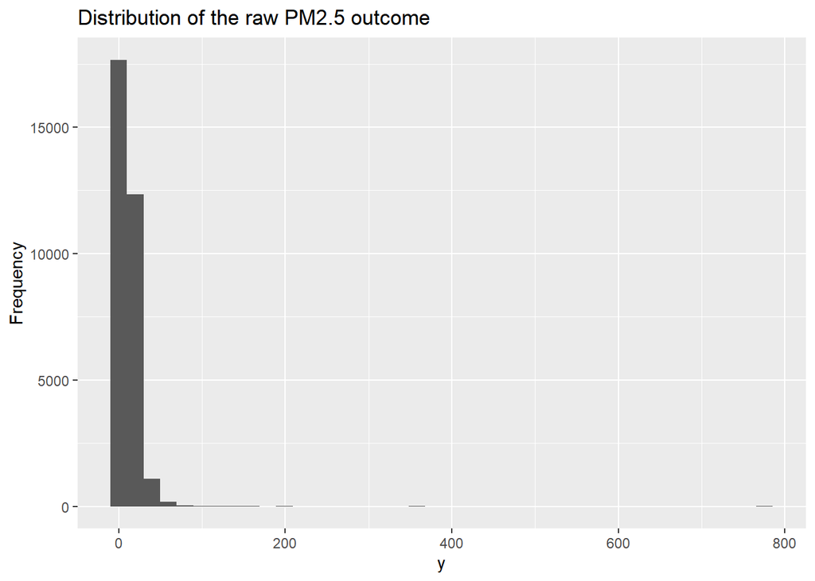

```r
# Histogram of raw outcome
ggplot(df, aes(x = .data[[outcome_var]])) +
  geom_histogram(bins = 40) +
  labs(
    title = "Distribution of the raw PM2.5 outcome",
    x = outcome_var,
    y = "Frequency"
  )
```

```r
# Skeweness of raw data
skew_raw <- skewness(df[[outcome_var]], na.rm = TRUE)
cat("Skewness (raw):", skew_raw, "\n")
```

```
## Skewness (raw): 17.05869
```

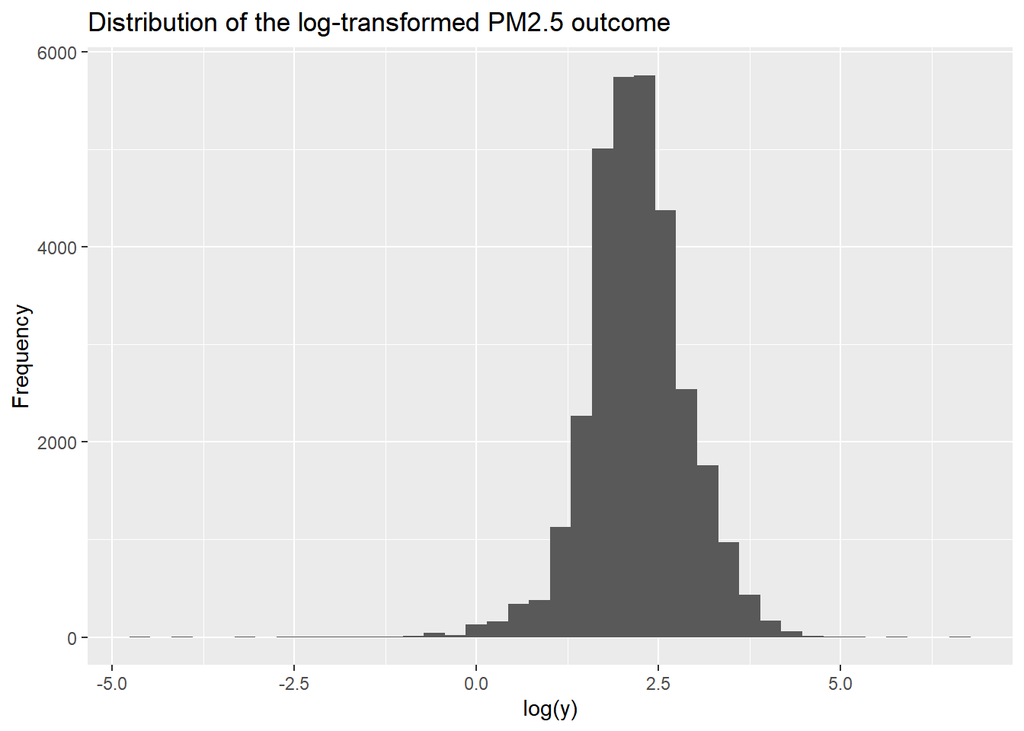

```r
# Histogram of log-transformed outcome
df_pos <- df %>% filter(.data[[outcome_var]] > 0)

ggplot(df_pos, aes(x = log(.data[[outcome_var]]))) +
  geom_histogram(bins = 40) +
  labs(
    title = "Distribution of the log-transformed PM2.5 outcome",
    x = paste0("log(", outcome_var, ")"),
    y = "Frequency"
  )
```

```r
# Skeweness of log data
skew_log <- skewness(log(df[[outcome_var]]), na.rm = TRUE)
cat("Skewness (log):", skew_log, "\n")
```

```
## Skewness (log): -0.2855041
```

```r
# Compare raw and log-scale summaries
cat("\nSummary of raw outcome:\n")
```

```
##
## Summary of raw outcome:
```

```r
print(summary(df_pos[[outcome_var]]))
```

```
##    Min. 1st Qu.  Median    Mean 3rd Qu.    Max.
##    0.01    6.00    9.00   11.33   13.40  775.60
```

```r
cat("\nSummary of log-transformed outcome:\n")
```

```
##
## Summary of log-transformed outcome:
```

```r
print(summary(log(df_pos[[outcome_var]])))
```

```
##    Min. 1st Qu.  Median    Mean 3rd Qu.    Max.
##  -4.605   1.792   2.197   2.193   2.595   6.654
```

## 3.2 2.2: data

```r
# 1. Observations per station
obs_per_station <- df %>%
  count(station_id, name = "n_obs") %>%
  arrange(desc(n_obs))

cat("Number of stations:", n_distinct(df$station_id), "\n")
```

```
## Number of stations: 116
```

```r
cat("Min observations per station:", min(obs_per_station$n_obs), "\n")
```

```
## Min observations per station: 69
```

```r
cat("Median observations per station:", median(obs_per_station$n_obs), "\n")
```

```
## Median observations per station: 299.5
```

```r
cat("Max observations per station:", max(obs_per_station$n_obs), "\n")
```

```
## Max observations per station: 332
```

```r
head(obs_per_station, 10)
```

```
## # A tibble: 10 × 2
##    station_id n_obs
##    <chr>      <int>
##  1 IT2254A      332
##  2 IT1906A      330
##  3 IT2023A      329
##  4 IT0863A      328
##  5 IT0889A      327
##  6 IT0956A      326
##  7 IT0825A      325
##  8 IT1836A      325
##  9 IT2174A      325
## 10 IT2247A      325
```

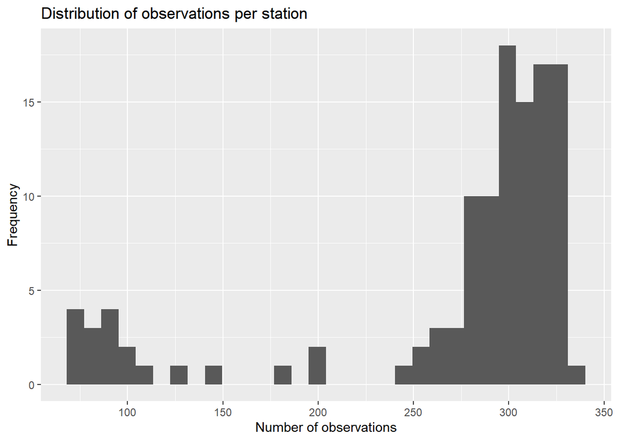

```r
ggplot(obs_per_station, aes(x = n_obs)) +
  geom_histogram(bins = 30) +
  labs(
    title = "Distribution of observations per station",
    x = "Number of observations",
    y = "Frequency"
  )
```

```r
# 2a Observations per month
obs_per_month <- df %>%
  count(month, name = "n_obs") %>%
  arrange(month)

print(obs_per_month)
```

```
## # A tibble: 12 × 2
##    month   n_obs
##    <fct>   <int>
##  1 2025-01   177
##  2 2025-02  2594
##  3 2025-03  3091
##  4 2025-04  2914
##  5 2025-05  2900
##  6 2025-06  2770
##  7 2025-07  2712
##  8 2025-08  2844
##  9 2025-09  2839
## 10 2025-10  2908
## 11 2025-11  2852
## 12 2025-12  2748
```

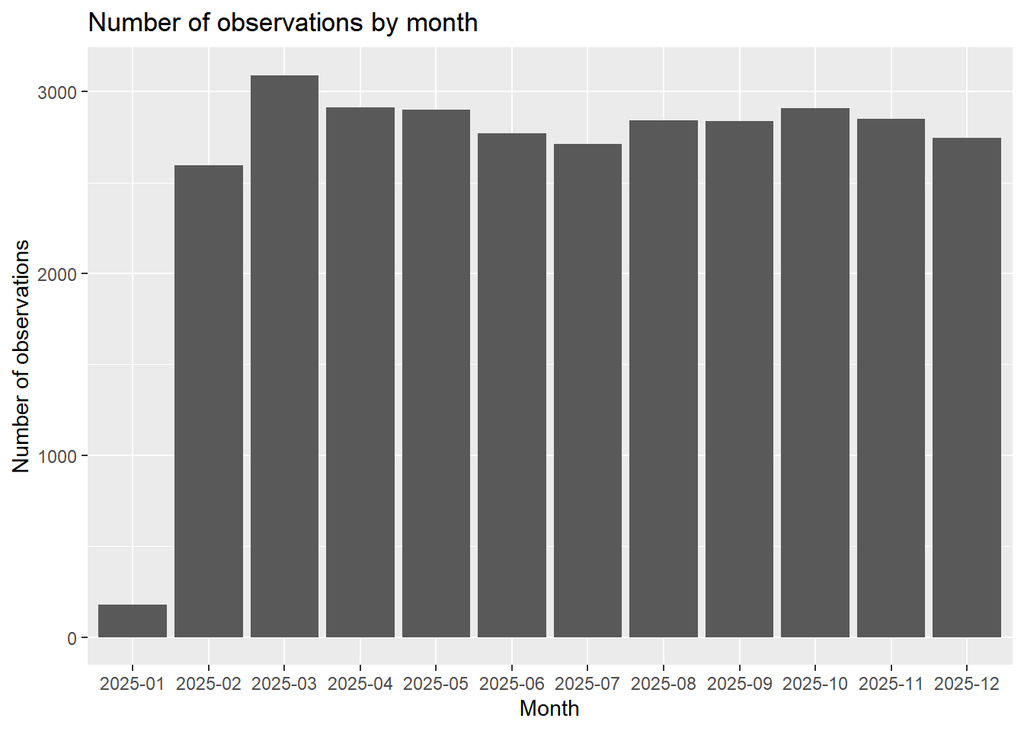

```r
ggplot(obs_per_month, aes(x = factor(month), y = n_obs)) +
  geom_col() +
  labs(
    title = "Number of observations by month",
    x = "Month",
    y = "Number of observations"
  )
```

```r
# 2b Observations per day of week
obs_per_day <- df %>%
  count(day_of_week, name = "n_obs")

print(obs_per_day)
```

```
## # A tibble: 7 × 2
##   day_of_week n_obs
##   <fct>       <int>
## 1 Mon          4485
## 2 Tue          4447
## 3 Wed          4415
## 4 Thu          4528
## 5 Fri          4513
## 6 Sat          4471
## 7 Sun          4490
```

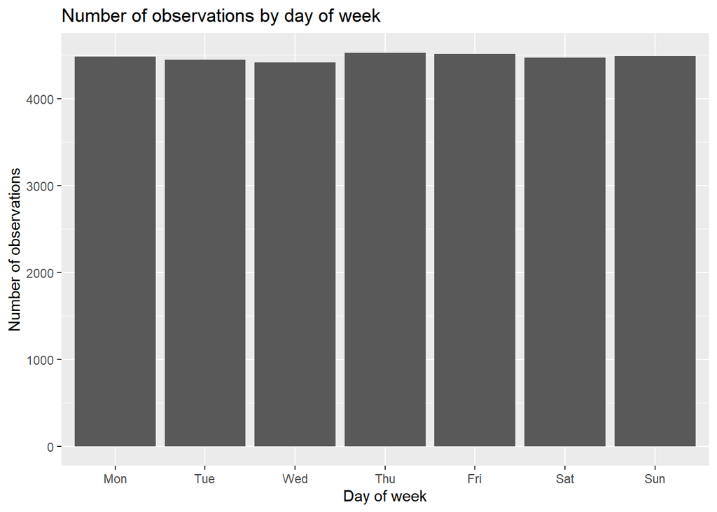

```r
ggplot(obs_per_day, aes(x = day_of_week, y = n_obs)) +
  geom_col() +
  labs(
    title = "Number of observations by day of week",
    x = "Day of week",
    y = "Number of observations"
  )
```

```r
# 3. Station-month panel structure
station_month <- df %>%
  distinct(station_id, month) %>%
  count(station_id, name = "n_months_present") %>%
  arrange(n_months_present, station_id)

cat("Min number of months observed per station:", min(station_month$n_months_present), "\n")
```

```
## Min number of months observed per station: 4
```

```r
cat("Median number of months observed per station:", median(station_month$n_months_present), "\n")
```

```
## Median number of months observed per station: 12
```

```r
cat("Max number of months observed per station:", max(station_month$n_months_present), "\n")
```

```
## Max number of months observed per station: 12
```

```r
head(station_month, 10)
```

```
## # A tibble: 10 × 2
##    station_id n_months_present
##    <chr>                 <int>
##  1 IT1830A                   4
##  2 IT1948A                   5
##  3 IT1788A                   7
##  4 IT2313A                   7
##  5 IT1740A                   8
##  6 IT1899A                   8
##  7 IT2202A                   8
##  8 IT2203A                   8
##  9 IT2204A                   8
## 10 IT2205A                   8
```

```r
# 4. Full station x month table and missing months
station_month_full <- expand_grid(
  station_id = sort(unique(df$station_id)),
  month = sort(unique(df$month))
) %>%
  left_join(
    df %>%
      count(station_id, month, name = "n_obs"),
    by = c("station_id", "month")
  ) %>%
  mutate(
    n_obs = ifelse(is.na(n_obs), 0, n_obs),
    missing_month = ifelse(n_obs == 0, 1, 0)
  )

missing_months_by_station <- station_month_full %>%
  group_by(station_id) %>%
  summarise(
    missing_months = sum(missing_month),
    months_observed = sum(n_obs > 0),
    .groups = "drop"
  ) %>%
  arrange(desc(missing_months), station_id)

cat("Stations with at least one completely missing month:",
    sum(missing_months_by_station$missing_months > 0), "\n")
```

```
## Stations with at least one completely missing month: 32
```

```r
head(missing_months_by_station, 15)
```

```
## # A tibble: 15 × 3
##    station_id missing_months months_observed
##    <chr>               <dbl>           <int>
##  1 IT1830A                 8               4
##  2 IT1948A                 7               5
##  3 IT1788A                 5               7
##  4 IT2313A                 5               7
##  5 IT1740A                 4               8
##  6 IT1899A                 4               8
##  7 IT2202A                 4               8
##  8 IT2203A                 4               8
##  9 IT2204A                 4               8
## 10 IT2205A                 4               8
## 11 IT1247A                 3               9
## 12 IT1487A                 3               9
## 13 IT2211A                 3               9
## 14 IT2268A                 3               9
## 15 IT2277A                 3               9
```

```r
# Optional: show which months are missing for each station
missing_month_detail <- station_month_full %>%
  filter(n_obs == 0) %>%
  arrange(station_id, month)

head(missing_month_detail, 20)
```

```
## # A tibble: 20 × 4
##    station_id month   n_obs missing_month
##    <chr>      <fct>   <dbl>         <dbl>
##  1 IT0952A    2025-01     0             1
##  2 IT1079A    2025-11     0             1
##  3 IT1079A    2025-12     0             1
##  4 IT1247A    2025-01     0             1
##  5 IT1247A    2025-02     0             1
##  6 IT1247A    2025-08     0             1
##  7 IT1487A    2025-10     0             1
##  8 IT1487A    2025-11     0             1
##  9 IT1487A    2025-12     0             1
## 10 IT1740A    2025-01     0             1
## 11 IT1740A    2025-02     0             1
## 12 IT1740A    2025-03     0             1
## 13 IT1740A    2025-04     0             1
## 14 IT1788A    2025-01     0             1
## 15 IT1788A    2025-02     0             1
## 16 IT1788A    2025-05     0             1
## 17 IT1788A    2025-09     0             1
## 18 IT1788A    2025-11     0             1
## 19 IT1830A    2025-01     0             1
## 20 IT1830A    2025-02     0             1
```

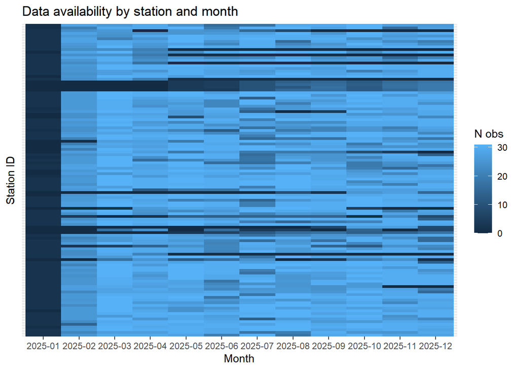

```r
# Heatmap of data availability by station and month
ggplot(station_month_full, aes(x = factor(month), y = factor(station_id), fill = n_obs)) +
  geom_tile() +
  labs(
    title = "Data availability by station and month",
    x = "Month",
    y = "Station ID",
    fill = "N obs"
  ) +
  theme(axis.text.y = element_blank(),
        axis.ticks.y = element_blank())
```

Exploratory analysis shows that the raw PM2.5 outcome is highly right-skewed, with a skewness of 17.06 and a long upper tail driven by extreme observations. After log transformation, skewness drops to -0.29, yielding a much more symmetric distribution and supporting the use of a Gaussian likelihood for the transformed outcome.

The panel structure is markedly unbalanced across monitoring stations. The number of observations per station ranges from 69 to 332, with a median of 299.5. The dataset is also uneven across months: while most months contain between roughly 2,600 and 3,100 observations, January is severely underrepresented, with only 177 observations. Moreover, 32 stations exhibit at least one completely missing month, and the minimum temporal coverage is only 4 months for some stations. These features support the use of a hierarchical specification, which is well suited to unbalanced grouped data.

# 4 3. Data preprocessing

```r
# Create log outcome and keep only finite values
df <- df %>%
  mutate(log_y = log(.data[[outcome_var]])) %>%
  filter(is.finite(log_y))

# Keep only variables used in the model and clean them
model_vars <- c("log_y", "station_id", "month", "day_of_week")

df_model <- df %>%
  dplyr::select(all_of(model_vars)) %>%
  drop_na() %>%
  mutate(
    station_id = factor(station_id),
    month = factor(month),
    day_of_week = factor(day_of_week)
  )

cat("Number of observations:", nrow(df_model), "\n")
```

```
## Number of observations: 31349
```

```r
cat("Number of stations:", n_distinct(df_model$station_id), "\n")
```

```
## Number of stations: 116
```

```r
# Summary of transformed outcome
df_model %>%
  summarise(
    n = n(),
    mean_log_y = mean(log_y),
    sd_log_y = sd(log_y),
    min_log_y = min(log_y),
    max_log_y = max(log_y)
  )
```

```
## # A tibble: 1 × 5
##       n mean_log_y sd_log_y min_log_y max_log_y
##   <int>      <dbl>    <dbl>     <dbl>     <dbl>
## 1 31349       2.19    0.686     -4.61      6.65
```

# 5 5. Design matrices and indexing

```r
# Fixed-effects matrix
X <- model.matrix(~ month + day_of_week, data = df_model)

# Outcome vector
y_tilde <- df_model$log_y

# Group index for stations
station_index <- as.integer(df_model$station_id)

# Dimensions
J <- nlevels(df_model$station_id)
n <- length(y_tilde)
p <- ncol(X)

# Number of observations per group
n_j <- as.integer(table(df_model$station_id))

cat("n =", n, "\n")
```

```
## n = 31349
```

```r
cat("p =", p, "\n")
```

```
## p = 18
```

```r
cat("J =", J, "\n")
```

```
## J = 116
```

```r
# check
head(X)
```

```
##   (Intercept) month2025-02 month2025-03 month2025-04 month2025-05 month2025-06
## 1           1            0            0            0            0            0
## 2           1            0            0            0            0            0
## 3           1            1            0            0            0            0
## 4           1            1            0            0            0            0
## 5           1            1            0            0            0            0
## 6           1            1            0            0            0            0
##   month2025-07 month2025-08 month2025-09 month2025-10 month2025-11 month2025-12
## 1            0            0            0            0            0            0
## 2            0            0            0            0            0            0
## 3            0            0            0            0            0            0
## 4            0            0            0            0            0            0
## 5            0            0            0            0            0            0
## 6            0            0            0            0            0            0
##   day_of_weekTue day_of_weekWed day_of_weekThu day_of_weekFri day_of_weekSat
## 1              0              0              1              0              0
## 2              0              0              0              1              0
## 3              0              0              0              0              1
## 4              0              0              0              0              0
## 5              0              0              0              0              0
## 6              1              0              0              0              0
##   day_of_weekSun
## 1              0
## 2              0
## 3              0
## 4              1
## 5              0
## 6              0
```

```r
table(df_model$month)
```

```
##
## 2025-01 2025-02 2025-03 2025-04 2025-05 2025-06 2025-07 2025-08 2025-09 2025-10
##     177    2594    3091    2914    2900    2770    2712    2844    2839    2908
## 2025-11 2025-12
##    2852    2748
```

```r
table(df_model$day_of_week)
```

```
##
##  Mon  Tue  Wed  Thu  Fri  Sat  Sun
## 4485 4447 4415 4528 4513 4471 4490
```

```r
summary(df_model$station_id)
```

```
## IT2254A IT1906A IT2023A IT0863A IT0889A IT0956A IT0825A IT1836A IT2174A IT2247A
##     332     330     329     328     327     326     325     325     325     325
## IT1184A IT2172A IT1183A IT1940A IT2100A IT2109A IT1900A IT2031A IT0992A IT1902A
##     324     324     323     323     323     323     322     322     321     321
## IT2087A IT2013A IT2252A IT0952A IT2004A IT0887A IT2026A IT2012A IT0867A IT0871A
##     321     319     319     318     318     317     317     315     314     314
## IT1143A IT1144A IT1182A IT2286A IT2249A IT1011A IT2308A IT1130A IT1510A IT2107A
##     314     314     314     314     313     312     311     310     308     308
## IT2134A IT2307A IT1365A IT0989A IT2128A IT0953A IT1222A IT2281A IT2117A IT2312A
##     308     308     307     306     306     305     305     305     304     304
## IT1180A IT1532A IT1871A IT1890A IT2089A IT2274A IT1128A IT2111A IT0957A IT2028A
##     303     303     303     301     301     301     300     300     299     299
## IT0470A IT2101A IT1523A IT2114A IT1883A IT2052A IT2251A IT2108A IT2118A IT2067A
##     298     298     297     297     296     296     296     295     294     293
## IT2294A IT2317A IT1065A IT2297A IT1596A IT2110A IT1078A IT1860A IT0885A IT0614A
##     292     292     289     289     288     288     287     286     285     284
## IT2093A IT2318A IT1728A IT2068A IT1904A IT2033A IT2094A IT2066A IT2105A IT1997A
##     283     283     282     282     281     279     279     277     275     274
## IT2064A IT2099A IT2275A IT1590A IT2104A IT2113A IT1079A IT1529A IT2078A (Other)
##     268     265     263     259     258     250     243     202     202    1648
```

# 6 6. Prior specification

```r
# -----------------------------
# Prior hyperparameters
# -----------------------------

# beta ~ N(b0, B0)
c_beta <- 100
b0 <- rep(0, p)
B0 <- diag(c_beta, p)
B0_inv <- solve(B0)

# sigma2 ~ IG(a_sigma, b_sigma)
a_sigma <- 2
b_sigma <- 0.5

# tau ~ Half-Cauchy(0, A)
A_tau <- 5

# -----------------------------
# MCMC settings
# -----------------------------
n_iter <- 5000
burn_in <- 1000

# proposal sd for log(tau)
proposal_sd_tau <- 0.15

# -----------------------------
# Initial values
# -----------------------------
beta_curr <- rep(0, p)
alpha_curr <- rep(0, J)
sigma2_curr <- var(y_tilde)
tau_curr <- 1

# -----------------------------
# Storage
# -----------------------------
beta_store <- matrix(NA_real_, nrow = n_iter, ncol = p)
alpha_store <- matrix(NA_real_, nrow = n_iter, ncol = J)
sigma2_store <- numeric(n_iter)
tau_store <- numeric(n_iter)
accept_tau <- logical(n_iter)
```

# 7 7. Full conditional formulas used in the sampler

The sampler uses the following updates:

$$\beta \mid \cdot \sim \mathcal N(m_\beta, V_\beta)$$

with

$$V_\beta = \left(B_0^{-1} + \frac{1}{\sigma^2}X'X\right)^{-1},
\qquad
m_\beta = V_\beta\left(B_0^{-1}b_0 + \frac{1}{\sigma^2}X'(\tilde y -
Z\alpha)\right)$$

$$\alpha_j \mid \cdot \sim \mathcal N(m_j, V_j)$$

with

$$V_j = \left(\frac{n_j}{\sigma^2} + \frac{1}{\tau^2}\right)^{-1},
\qquad
m_j = V_j\frac{1}{\sigma^2}\sum_{i \in j}(\tilde y_i - x_i'\beta)$$

$$\sigma^2 \mid \cdot \sim IG\left(a_\sigma + \frac{n}{2}, b_\sigma +
\frac{SSR}{2}\right)$$

For $\tau$, the full conditional is only known up to proportionality, so a Metropolis-Hastings step is used.

# 8 8. Utility functions for the sampler

```r
# Draw from Inverse-Gamma(shape, scale) under the convention:
# p(x) prop to x^{-(a+1)} exp(-b/x)
# If G ~ Gamma(shape=a, rate=b), then 1/G ~ IG(a,b)
rinvgamma <- function(n, shape, scale) {
  1 / rgamma(n, shape = shape, rate = scale)
}

# Log-target for eta = log(tau)
log_target_eta <- function(eta, alpha, A_tau) {
  J <- length(alpha)
  S_alpha <- sum(alpha^2)
  -(J - 1) * eta - S_alpha / (2 * exp(2 * eta)) - log(1 + exp(2 * eta) / A_tau^2)
}
```

# 9 9. Metropolis-within-Gibbs sampler

```r
run_mwg_sampler <- function(y_tilde, X, station_index, n_j,
                            b0, B0, a_sigma, b_sigma, A_tau,
                            n_iter = 5000,
                            proposal_sd = 0.15,
                            seed = 123) {

  set.seed(seed)

  n <- length(y_tilde)
  p <- ncol(X)
  J <- length(n_j)
  B0_inv <- solve(B0)

  if (any(is.na(station_index))) stop("station_index contains NA")
  if (min(station_index) < 1) stop("station_index contains values < 1")
  if (max(station_index) > J) stop("station_index exceeds number of groups")
  if (burn_in >= n_iter) stop("burn_in must be smaller than n_iter")

  # Storage
  beta_store <- matrix(NA_real_, nrow = n_iter, ncol = p)
  alpha_store <- matrix(NA_real_, nrow = n_iter, ncol = J)
  sigma2_store <- numeric(n_iter)
  tau_store <- numeric(n_iter)
  accept_tau <- logical(n_iter)

  # Initial values
  beta_curr <- rep(0, p)
  alpha_curr <- rep(0, J)
  sigma2_curr <- var(y_tilde)
  tau_curr <- 1

  XtX <- crossprod(X)

  for (t in seq_len(n_iter)) {

    # ---- 1. Gibbs update for beta ----
    alpha_vec <- alpha_curr[station_index]

    precision_beta <- B0_inv + XtX / sigma2_curr
    V_beta <- solve(precision_beta)
    V_beta <- 0.5 * (V_beta + t(V_beta))

    term_prior <- B0_inv %*% b0
    term_lik <- crossprod(X, y_tilde - alpha_vec) / sigma2_curr
    rhs_beta <- term_prior + term_lik
    m_beta <- solve(precision_beta, rhs_beta)

    if (any(!is.finite(m_beta))) {
      stop(paste("m_beta contains non-finite values at iteration", t))
    }

    beta_curr <- as.numeric(MASS::mvrnorm(
      1,
      mu = as.numeric(m_beta),
      Sigma = V_beta
      ))

    # ---- 2. Gibbs updates for alpha_j ----
    xb <- as.numeric(X %*% beta_curr)

    for (j in seq_len(J)) {
      idx <- which(station_index == j)
      V_j <- 1 / (n_j[j] / sigma2_curr + 1 / (tau_curr^2))
      m_j <- V_j * sum(y_tilde[idx] - xb[idx]) / sigma2_curr
      alpha_curr[j] <- rnorm(1, mean = m_j, sd = sqrt(V_j))
    }

    # ---- 3. Gibbs update for sigma^2 ----
    resid <- y_tilde - xb - alpha_curr[station_index]
    SSR <- sum(resid^2)
    sigma2_curr <- rinvgamma(
      1,
      shape = a_sigma + n / 2,
      scale = b_sigma + SSR / 2
      )

    if (!is.finite(sigma2_curr) || sigma2_curr <= 0) {
      stop(paste("sigma2_curr became invalid at iteration", t))
    }

    # ---- 4. MH update for tau on log scale ----
    eta_curr <- log(tau_curr)
    eta_prop <- rnorm(1, mean = eta_curr, sd = proposal_sd)

    log_r <- log_target_eta(eta_prop, alpha_curr, A_tau) -
      log_target_eta(eta_curr, alpha_curr, A_tau)

    if (log(runif(1)) < log_r) {
      tau_curr <- exp(eta_prop)
      accept_tau[t] <- TRUE
    } else {
      accept_tau[t] <- FALSE
    }

    # ---- Store current draws ----
    beta_store[t, ] <- beta_curr
    alpha_store[t, ] <- alpha_curr
    sigma2_store[t] <- sigma2_curr
    tau_store[t] <- tau_curr
  }

  list(
    beta = beta_store,
    alpha = alpha_store,
    sigma2 = sigma2_store,
    tau = tau_store,
    accept_tau = accept_tau,
    accept_rate_tau_all = mean(accept_tau)
  )
}
```

# 10 9b. Postprocessing

```r
post_process_mcmc <- function(mcmc_fit, burn_in = 100, thin = 1) {
  n_iter <- nrow(mcmc_fit$beta)
  if (burn_in >= n_iter) stop("burn_in must be smaller than total iterations")
  if (thin < 1) stop("thin must be >= 1")

  kept <- seq(from = burn_in + 1, to = n_iter, by = thin)

  list(
    post_beta = mcmc_fit$beta[kept, , drop = FALSE],
    post_alpha = mcmc_fit$alpha[kept, , drop = FALSE],
    post_sigma2 = mcmc_fit$sigma2[kept],
    post_tau = mcmc_fit$tau[kept],
    accept_rate_tau = mean(mcmc_fit$accept_tau[kept]),
    kept_iterations = kept
  )
}
```

# 11 10. Run the sampler

```r
# MASS::mvrnorm is used inside the function
library(MASS)

mcmc_fit <- run_mwg_sampler(
  y_tilde = y_tilde,
  X = X,
  station_index = station_index,
  n_j = n_j,
  b0 = b0,
  B0 = B0,
  a_sigma = a_sigma,
  b_sigma = b_sigma,
  A_tau = A_tau,
  n_iter = 5000,
  proposal_sd = 0.2,
  seed = 123
)

mcmc_fit$accept_rate_tau_all
```

```
## [1] 0.3782
```

# 12 10b. Trace plots

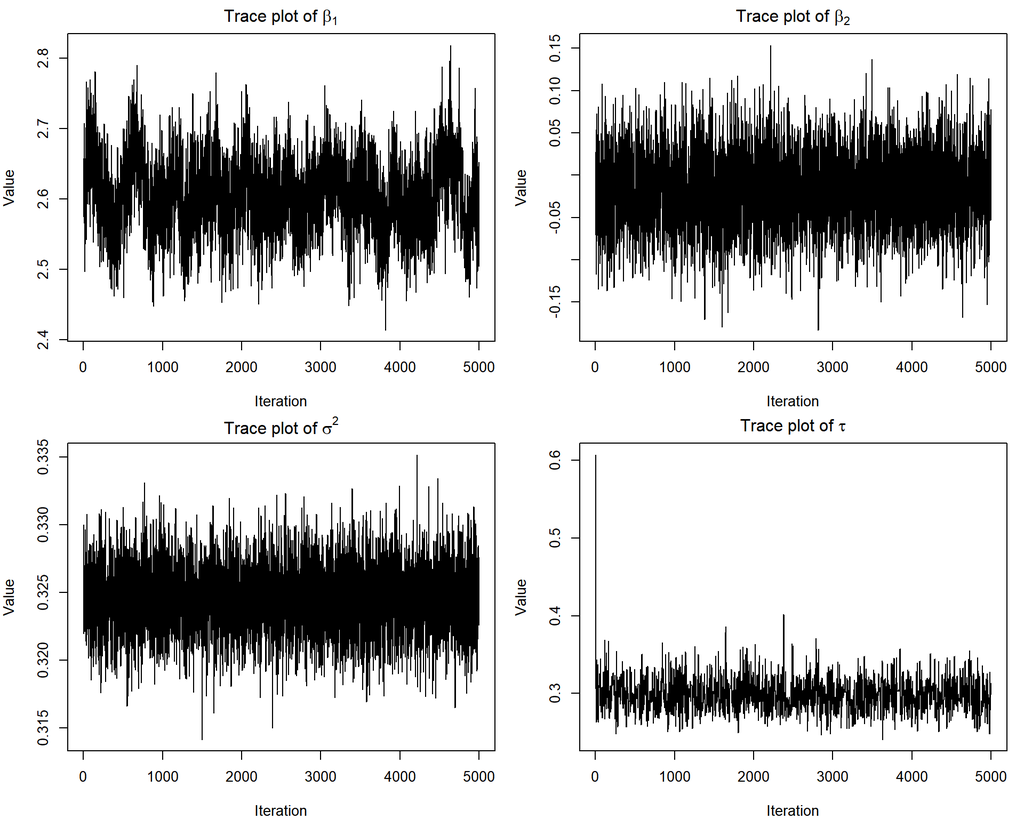

```r
par(mfrow = c(2, 2), mar = c(4, 4, 2, 1))

plot(mcmc_fit$beta[, 1], type = "l",
     main = expression(paste("Trace plot of ", beta[1])),
     xlab = "Iteration", ylab = "Value")

plot(mcmc_fit$beta[, 2], type = "l",
     main = expression(paste("Trace plot of ", beta[2])),
     xlab = "Iteration", ylab = "Value")

plot(mcmc_fit$sigma2, type = "l",
     main = expression(paste("Trace plot of ", sigma^2)),
     xlab = "Iteration", ylab = "Value")

plot(mcmc_fit$tau, type = "l",
     main = expression(paste("Trace plot of ", tau)),
     xlab = "Iteration", ylab = "Value")
```

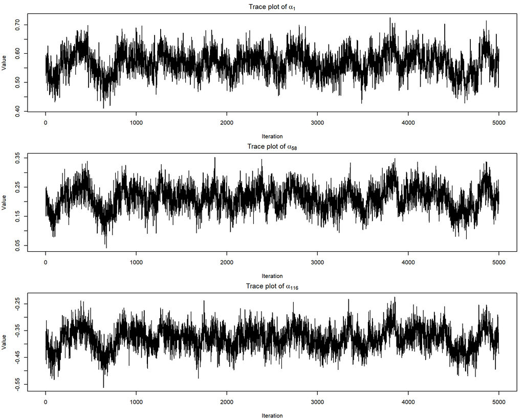

```r
J <- ncol(mcmc_fit$alpha)
alpha_idx <- unique(c(1, round(J / 2), J))

par(mfrow = c(length(alpha_idx), 1), mar = c(4, 4, 2, 1))

for (j in alpha_idx) {
  plot(mcmc_fit$alpha[, j], type = "l",
       main = bquote(paste("Trace plot of ", alpha[.(j)])),
       xlab = "Iteration", ylab = "Value")
}
```

# 13 10c. ACF

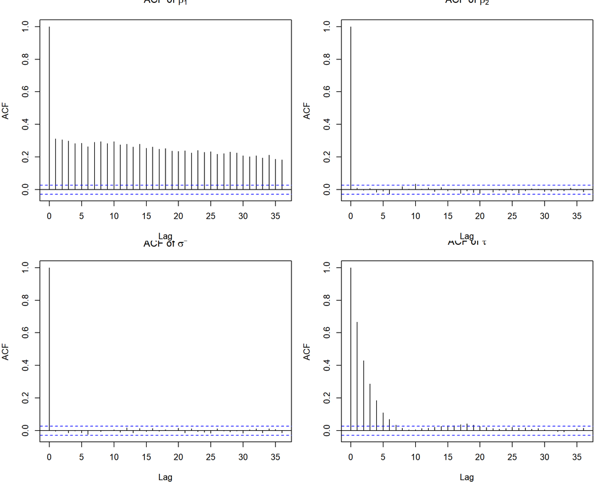

```r
par(mfrow = c(2, 2), mar = c(4, 4, 2, 1))

acf(mcmc_fit$beta[, 1],
    main = expression(paste("ACF of ", beta[1])))

acf(mcmc_fit$beta[, 2],
    main = expression(paste("ACF of ", beta[2])))

acf(mcmc_fit$sigma2,
    main = expression(paste("ACF of ", sigma^2)))

acf(mcmc_fit$tau,
    main = expression(paste("ACF of ", tau)))
```

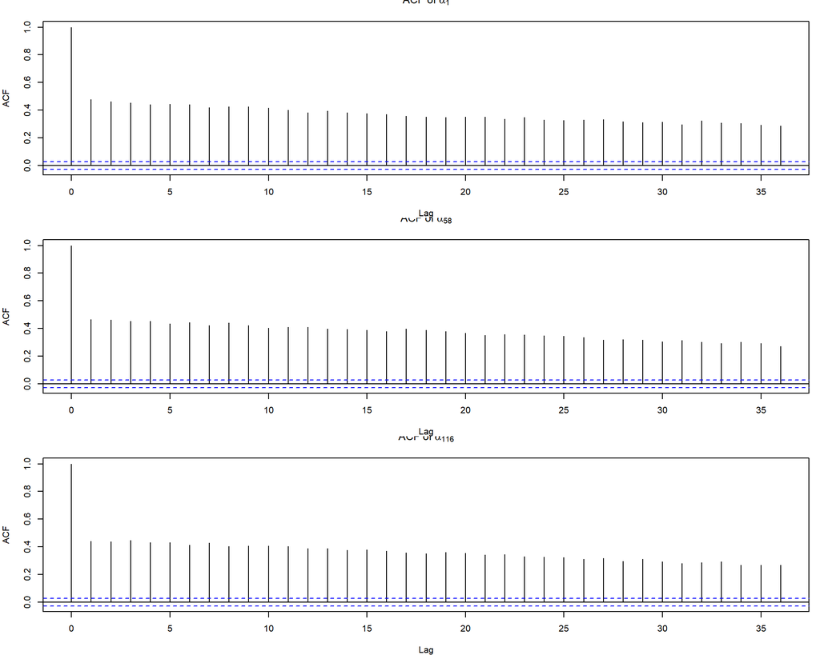

```r
par(mfrow = c(length(alpha_idx), 1), mar = c(4, 4, 2, 1))

for (j in alpha_idx) {
  acf(mcmc_fit$alpha[, j],
      main = bquote(paste("ACF of ", alpha[.(j)])))
}
```

# 14 10d. Choose burn in iterations

```r
burn_in <- 200

post <- post_process_mcmc(mcmc_fit, burn_in = burn_in, thin = 5)

post$accept_rate_tau
```

```
## [1] 0.3875
```

#10e. Trace plots after burn-in

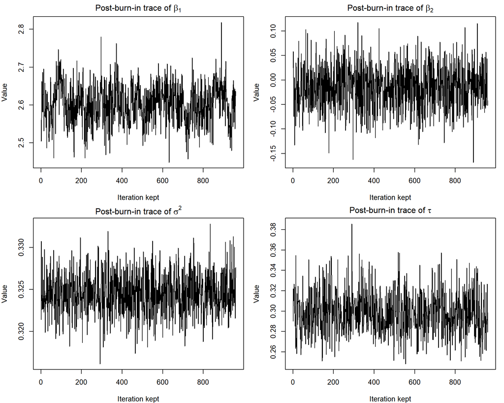

```r
par(mfrow = c(2, 2), mar = c(4, 4, 2, 1))

plot(post$post_beta[, 1], type = "l",
     main = expression(paste("Post-burn-in trace of ", beta[1])),
     xlab = "Iteration kept", ylab = "Value")

plot(post$post_beta[, 2], type = "l",
     main = expression(paste("Post-burn-in trace of ", beta[2])),
     xlab = "Iteration kept", ylab = "Value")

plot(post$post_sigma2, type = "l",
     main = expression(paste("Post-burn-in trace of ", sigma^2)),
     xlab = "Iteration kept", ylab = "Value")

plot(post$post_tau, type = "l",
     main = expression(paste("Post-burn-in trace of ", tau)),
     xlab = "Iteration kept", ylab = "Value")
```

### Visual inspection The trace plots of the post-burn-in chains show no evidence of non-stationarity or systematic trends. All parameters fluctuate around stable levels, suggesting that the burn-in period has successfully removed the initial transient phase. The chains exhibit satisfactory mixing, although some residual autocorrelation is visible for selected parameters. Overall, the visual inspection supports convergence and justifies the use of the retained samples for posterior inference.

# 15 10f. ACF post burn-in

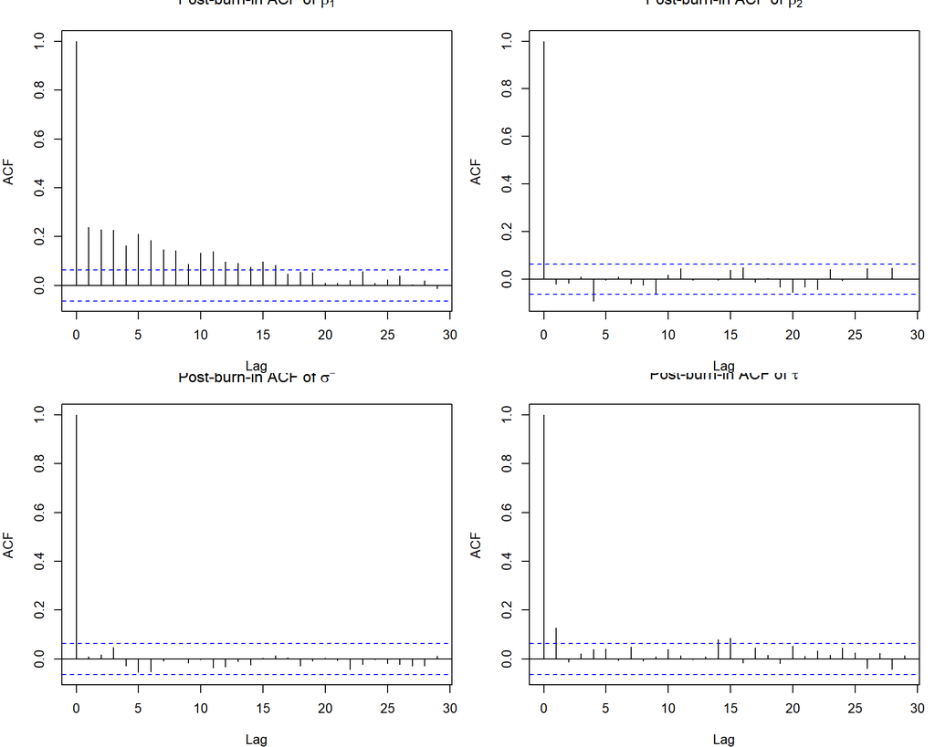

```r
par(mfrow = c(2, 2), mar = c(4, 4, 2, 1))

acf(post$post_beta[, 1],
    main = expression(paste("Post-burn-in ACF of ", beta[1])))

acf(post$post_beta[, 2],
    main = expression(paste("Post-burn-in ACF of ", beta[2])))

acf(post$post_sigma2,
    main = expression(paste("Post-burn-in ACF of ", sigma^2)))

acf(post$post_tau,
    main = expression(paste("Post-burn-in ACF of ", tau)))
```

# 10g. ESS

```r
library(coda)

mcmc_beta   <- mcmc(post$post_beta)
mcmc_alpha  <- mcmc(post$post_alpha)
mcmc_sigma2 <- mcmc(post$post_sigma2)
mcmc_tau    <- mcmc(post$post_tau)

effectiveSize(mcmc_beta)
```

```
##      var1      var2      var3      var4      var5      var6      var7      var8
##  178.4195 1215.3986  960.0000  960.0000  960.0000  960.0000  960.0000  960.0000
##      var9     var10     var11     var12     var13     var14     var15     var16
##  960.0000  960.0000  960.0000  960.0000  960.0000  960.0000  960.0000  960.0000
##     var17     var18
##  960.0000  960.0000
```

```r
effectiveSize(mcmc_alpha)
```

```
##      var1      var2      var3      var4      var5      var6      var7      var8
##  77.31887 138.04737  85.07854  77.20666  97.62129 127.91207  84.39061  93.07811
##      var9     var10     var11     var12     var13     var14     var15     var16
## 108.82669  86.72049 107.05423 106.25715 100.92763  98.13364  75.13184 115.60673
##     var17     var18     var19     var20     var21     var22     var23     var24
##  87.52595 100.58386  99.83505  86.62592  92.55955  95.81918  83.68467  78.14120
##     var25     var26     var27     var28     var29     var30     var31     var32
##  97.21220 114.79240 100.02824  88.81251 241.63130  65.90789 309.27116  80.16786
##     var33     var34     var35     var36     var37     var38     var39     var40
##  97.80751 121.77930  80.11136 118.88900 109.35149  93.57674 210.54151 239.82155
##     var41     var42     var43     var44     var45     var46     var47     var48
## 263.42533 115.77508  81.18561  76.28422 207.70041 104.56468 104.62707 107.74697
##     var49     var50     var51     var52     var53     var54     var55     var56
##  88.45657  83.99633  82.01833  96.44818 103.91842 331.73363 110.84804 108.31592
##     var57     var58     var59     var60     var61     var62     var63     var64
##  87.54468  76.67296 103.60831  65.89096 107.51303  89.63649 109.25642  81.61830
##     var65     var66     var67     var68     var69     var70     var71     var72
##  93.49420  85.20361 106.48514 118.46933 117.72795  88.41029 125.61047  75.01037
##     var73     var74     var75     var76     var77     var78     var79     var80
##  95.94259  86.44177  79.86536  76.01577 136.52852  77.61638 116.65849  86.07406
##     var81     var82     var83     var84     var85     var86     var87     var88
##  87.66997 110.56194 122.92568  89.15714  88.41709 109.27010 113.59730  96.53816
##     var89     var90     var91     var92     var93     var94     var95     var96
##  70.47446 105.27801  90.69108 250.11348 341.11590 287.82932 159.20758 352.85200
##     var97     var98     var99    var100    var101    var102    var103    var104
##  97.68549  86.62640  93.95693 122.21882  91.00623 265.83802  88.31744  86.13802
##    var105    var106    var107    var108    var109    var110    var111    var112
## 182.10134 122.40150 272.04181  85.76792  72.14616 100.25281 109.15425  85.26331
##    var113    var114    var115    var116
## 103.43023 178.07090  79.15976 112.36994
```

```r
effectiveSize(mcmc_sigma2)
```

```
## var1
##  960
```

```r
effectiveSize(mcmc_tau)
```

```
##     var1
## 742.9954
```

Due to autocorrelation in the MCMC draws, the effective sample size (ESS) is used to assess the amount of independent information in the chain. The ESS values are sufficiently large, indicating good mixing of the sampler.

# 16 11. Posterior summaries

```r
posterior_summary <- function(x) {
  c(
    mean = mean(x),
    sd = sd(x),
    q2.5 = quantile(x, 0.025),
    median = median(x),
    q97.5 = quantile(x, 0.975)
  )
}

beta_summary <- t(apply(post$post_beta, 2, posterior_summary))
sigma2_summary <- posterior_summary(post$post_sigma2)
tau_summary <- posterior_summary(post$post_tau)

beta_summary
```

```
##               mean         sd    q2.5.2.5%       median  q97.5.97.5%
##  [1,]  2.603418081 0.05227638  2.503088301  2.604618751  2.698884667
##  [2,] -0.015749356 0.04485902 -0.098919389 -0.014005639  0.069808638
##  [3,] -0.362021522 0.04479207 -0.445499340 -0.361363611 -0.274977980
##  [4,] -0.614974779 0.04461996 -0.697072516 -0.614183738 -0.528397762
##  [5,] -0.741661508 0.04475021 -0.826890367 -0.741035716 -0.657262894
##  [6,] -0.119440301 0.04482782 -0.202748396 -0.117612860 -0.031183765
##  [7,] -0.597696184 0.04499852 -0.681118148 -0.597782345 -0.506304894
##  [8,] -0.425342330 0.04502280 -0.507909098 -0.425383033 -0.341742110
##  [9,] -0.799916326 0.04538712 -0.884326920 -0.799863960 -0.709958316
## [10,] -0.605106712 0.04494935 -0.689595761 -0.603978984 -0.518062816
## [11,] -0.380865249 0.04504541 -0.466546496 -0.381069863 -0.291663007
## [12,] -0.067539893 0.04518908 -0.150266467 -0.066730800  0.019025060
## [13,]  0.010123663 0.01190534 -0.012221034  0.009866626  0.034299241
## [14,]  0.007590409 0.01218215 -0.015439528  0.007740871  0.031843365
## [15,]  0.001124320 0.01233144 -0.022907245  0.001650826  0.025221625
## [16,]  0.012202543 0.01179446 -0.009870504  0.012029936  0.034668027
## [17,]  0.024737899 0.01200304  0.001580576  0.024947168  0.047981173
## [18,] -0.017148195 0.01187840 -0.040633864 -0.017234633  0.005620652
```

```r
sigma2_summary
```

```
##        mean          sd   q2.5.2.5%      median q97.5.97.5%
## 0.324508332 0.002530976 0.319686983 0.324396601 0.329439915
```

```r
tau_summary
```

```
##        mean          sd   q2.5.2.5%      median q97.5.97.5%
##  0.29850692  0.02047837  0.26102340  0.29699114  0.34312950
```

Inspection of the trace plots suggested only a short transient phase, so the first 200 iterations were discarded as burn-in. Residual autocorrelation remained for some parameters, especially the intercept and selected random effects; therefore, a mild thinning scheme (every 5th draw) was applied. The retained chains appeared stable, and the acceptance rate for the Metropolis-Hastings update of τ was satisfactory.

# 17 13. Sensitivity analysis skeleton

This section presents a simple sensitivity analysis to compare prior choices such as: - $c \in \{10, 100, 1000\}$ for $B_0 = cI$ - $A \in \{2.5, 5, 10\}$ for the half-Cauchy prior on $\tau$ - $b_\sigma \in \{0.5, 1\}$ for the inverse-gamma prior on $\sigma^2$

```r
run_one_spec <- function(c_prior, A_tau, b_sigma,
                         scenario = NA_character_,
                         n_iter = 5000,
                         burn_in = 200,
                         thin = 5,
                         seed = 123) {

  fit <- run_mwg_sampler(
    y_tilde = y_tilde,
    X = X,
    station_index = station_index,
    n_j = n_j,
    b0 = rep(0, ncol(X)),
    B0 = diag(c_prior, ncol(X)),
    a_sigma = 2,
    b_sigma = b_sigma,
    A_tau = A_tau,
    n_iter = n_iter,
    proposal_sd = 0.2,
    seed = seed
  )

  post <- post_process_mcmc(
    mcmc_fit = fit,
    burn_in = burn_in,
    thin = thin
  )

  data.frame(
    scenario = scenario,
    c_prior = c_prior,
    A_tau = A_tau,
    b_sigma = b_sigma,
    beta_intercept_mean = mean(post$post_beta[, 1]),
    sigma2_mean = mean(post$post_sigma2),
    tau_mean = mean(post$post_tau),
    tau_accept_post = post$accept_rate_tau
  )
}
```

# 18 One-at-a-time sensitivity analysis

```r
baseline_row <- data.frame(
  scenario = "Baseline",
  c_prior = 100,
  A_tau = 5,
  b_sigma = 0.5,
  beta_intercept_mean = mean(post$post_beta[, 1]),
  sigma2_mean = mean(post$post_sigma2),
  tau_mean = mean(post$post_tau),
  tau_accept_post = post$accept_rate_tau
)

sensitivity_results <- bind_rows(
  baseline_row,
  run_one_spec(10,  5, 0.5, scenario = "B0 smaller"),
  run_one_spec(1000, 5, 0.5, scenario = "B0 larger"),
  run_one_spec(100, 2.5, 0.5, scenario = "A_tau smaller"),
  run_one_spec(100, 10, 0.5, scenario = "A_tau larger"),
  run_one_spec(100, 5, 1, scenario = "b_sigma larger")
)

sensitivity_results
```

```
##         scenario c_prior A_tau b_sigma beta_intercept_mean sigma2_mean
## 1       Baseline     100   5.0     0.5            2.603418   0.3245083
## 2     B0 smaller      10   5.0     0.5            2.601836   0.3245083
## 3      B0 larger    1000   5.0     0.5            2.603480   0.3245082
## 4  A_tau smaller     100   2.5     0.5            2.603325   0.3245082
## 5   A_tau larger     100  10.0     0.5            2.603418   0.3245083
## 6 b_sigma larger     100   5.0     1.0            2.603363   0.3245404
##    tau_mean tau_accept_post
## 1 0.2985069       0.3875000
## 2 0.2983755       0.3937500
## 3 0.2986517       0.4010417
## 4 0.2988245       0.3843750
## 5 0.2985069       0.3875000
## 6 0.2981771       0.3927083
```

The sensitivity analysis shows that posterior estimates are remarkably stable across a wide range of prior specifications. In particular, the posterior mean of the intercept, the residual variance σ^2, and the hyperparameter τ remain virtually unchanged when varying the prior scale c, the hyperparameter A, and the inverse-gamma parameter b_σ. As expected, the hyperparameter τ shows slightly higher sensitivity compared to the regression coefficients, although the magnitude of variation remains negligible. This suggests that the data are highly informative and that the posterior distribution is largely driven by the likelihood rather than the prior. The results are therefore robust to reasonable prior choices.

# 19 14. CODA: GEWEKE

```r
library(coda)

mcmc_beta1  <- mcmc(post$post_beta[, 1])
mcmc_beta2  <- mcmc(post$post_beta[, 2])
mcmc_sigma2 <- mcmc(post$post_sigma2)
mcmc_tau    <- mcmc(post$post_tau)

geweke_results <- data.frame(
  parameter = c("beta_1", "beta_2", "sigma2", "tau"),
  z_score = c(
    geweke.diag(mcmc_beta1)$z,
    geweke.diag(mcmc_beta2)$z,
    geweke.diag(mcmc_sigma2)$z,
    geweke.diag(mcmc_tau)$z
  )
)

geweke_results
```

```
##   parameter    z_score
## 1    beta_1  0.2233956
## 2    beta_2 -0.7608000
## 3    sigma2 -0.6490586
## 4       tau -0.2004884
```

```r
J <- ncol(post$post_alpha)
alpha_idx <- unique(c(1, round(J / 2), J))

alpha_geweke <- data.frame(
  parameter = paste0("alpha_", alpha_idx),
  z_score = sapply(alpha_idx, function(j) geweke.diag(mcmc(post$post_alpha[, j]))$z)
)

alpha_geweke
```

```
##   parameter     z_score
## 1   alpha_1  0.11113809
## 2  alpha_58 -0.03092227
## 3 alpha_116  0.06347014
```

The Geweke diagnostic provides no evidence against convergence. All z-scores are well below the conventional threshold of 1.96 in absolute value, both for the main model parameters and for the selected random effects. This finding is consistent with the visual inspection of the trace plots and supports the use of the retained draws for posterior inference.

# 20 15. PPC

```r
# Number of posterior draws to use for PPC
S <- min(100, nrow(post$post_beta))

set.seed(123)

# Randomly select posterior draws
draw_ids <- sample(seq_len(nrow(post$post_beta)), S)

# Matrix to store replicated datasets
yrep_mat <- matrix(NA_real_, nrow = length(y_tilde), ncol = S)

for (s in seq_along(draw_ids)) {
  d <- draw_ids[s]

  beta_s   <- post$post_beta[d, ]
  alpha_s  <- post$post_alpha[d, ]
  sigma2_s <- post$post_sigma2[d]

  mu_s <- as.vector(X %*% beta_s) + alpha_s[station_index]

  yrep_mat[, s] <- rnorm(
    n = length(y_tilde),
    mean = mu_s,
    sd = sqrt(sigma2_s)
  )
}
```

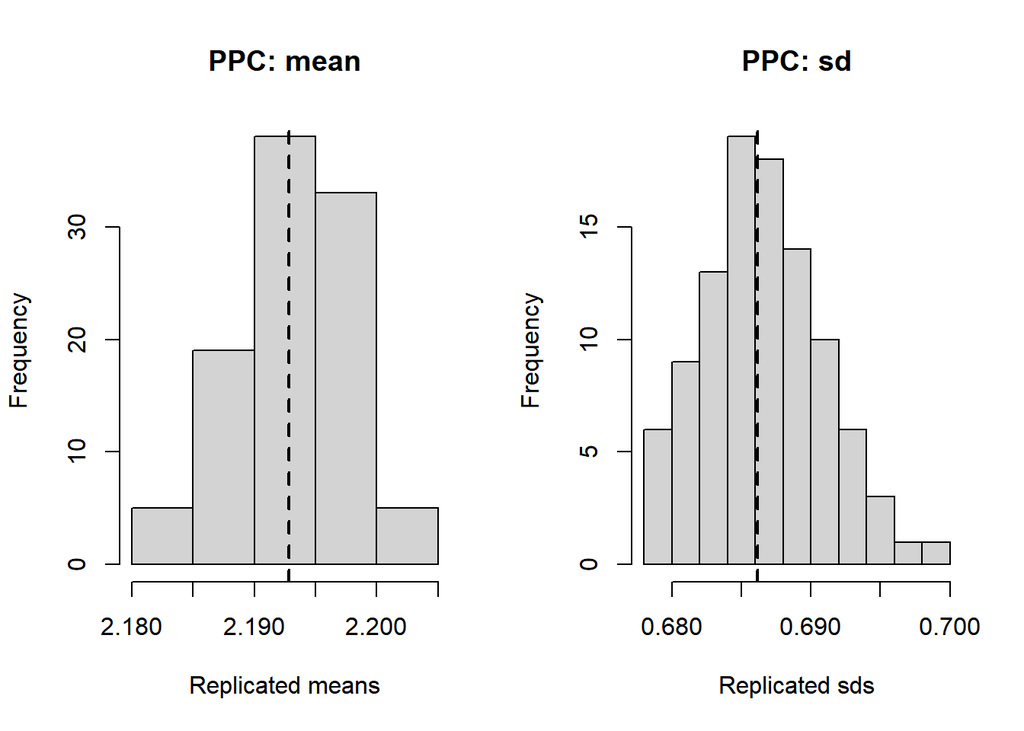

```r
obs_mean <- mean(y_tilde)
obs_sd   <- sd(y_tilde)

rep_means <- apply(yrep_mat, 2, mean)
rep_sds   <- apply(yrep_mat, 2, sd)

par(mfrow = c(1, 2))

hist(rep_means, main = "PPC: mean", xlab = "Replicated means")
abline(v = obs_mean, lwd = 2, lty = 2)

hist(rep_sds, main = "PPC: sd", xlab = "Replicated sds")
abline(v = obs_sd, lwd = 2, lty = 2)
```

```r
par(mfrow = c(1, 1))
```

## 20.1 Visualization

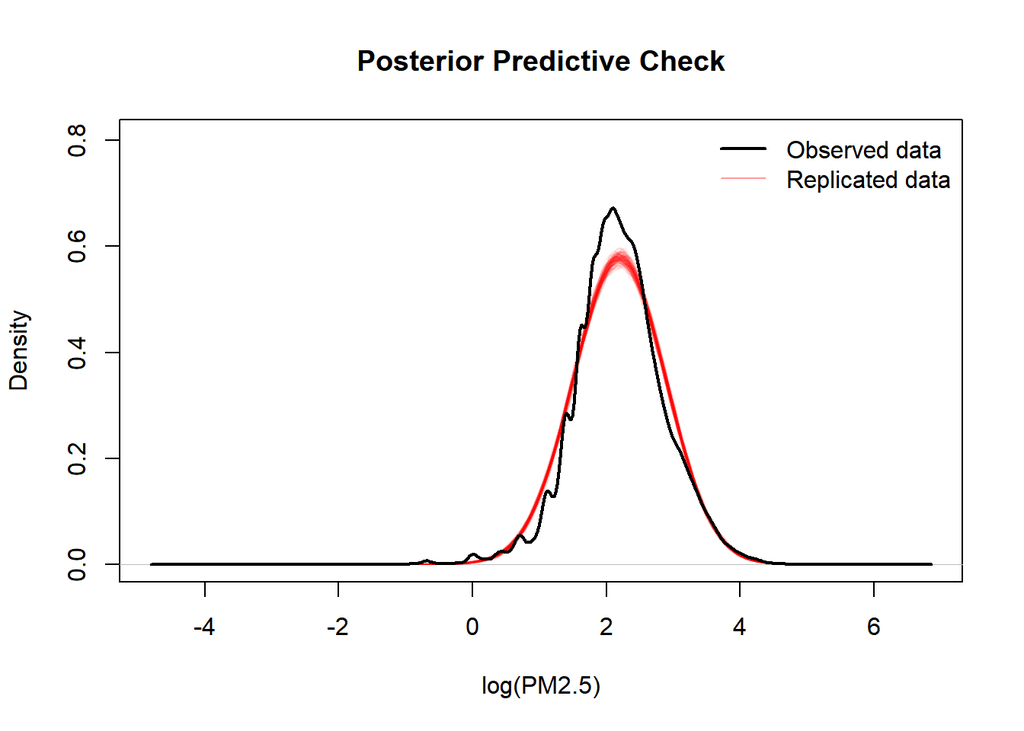

```r
plot(density(y_tilde),
     lwd = 2,
     main = "Posterior Predictive Check",
     xlab = "log(PM2.5)",
     ylim = c(0, max(density(y_tilde)$y) * 1.2))

for (s in 1:S) {
  lines(density(yrep_mat[, s]), col = rgb(1, 0, 0, 0.08))
}

lines(density(y_tilde), lwd = 2)
legend("topright",
       legend = c("Observed data", "Replicated data"),
       lwd = c(2, 1),
       col = c("black", rgb(1, 0, 0, 0.4)),
       bty = "n")
```